# Bangla MEG SaVANT Analysis

Author

Swarnendu Moitra

```r
path <- getwd()
level_order <- c('Gramm', 'CatViol', 'SemViol')
```

# Load Libraries

```r
library(lme4)
library(tidyverse)
library(glmm)
library(ggplot2)
library(afex)
library(trimr)
require(car)
require(lattice)
require(itsadug)
library(ggpubr)
library(languageR)
library(plotrix)
library(Hmisc)
library(rlist)
library(effects)
library(sjPlot)
library(effectsize)
library(trimr)
library(jtools)
library(plotrix)
library(ggpubr)
library(gridExtra)
library(grid)
library(ggthemes)
source('data/Themes.R')
```

# MEG

## PRE DECOMPOSITION

### Tark Localiser

6 conditions in this experiment, with 50 trials each. These conditions vary in length and Gaussian noise level as a visual mask. The trials were either 1-element or 4-element items. The 1-element items included 4 unique one-symbol items presented at the lowest Gaussian noise level (level 1), and 26 unique one-letter items presented at both the lowest (level 1) and highest Gaussian noise level (level 24). The one-symbol items were a triangle, a square, a diamond, or a circle **each containing a bar-diacritic over the element** and the one-letter items consisted single Bangla consonants. The 4-element items were 4-symbol strings presented only at the lowest Gaussian level (level 1) and 50 4-letter monomorphemic Bangla words presented at both noise level 1 and level 24. The four symbols used were again triangle, square, diamond, and circle, and were presented in four different permutations, joined together by a bar. Taking together we had a total of 300 trials in this experiment.

Analysis below is follwing Gwillams et al 2016

**Length**: 1 & 4

**Noise**: Level 1 & Level 24

**StimulusType**: symbol & letter

`We removed 1 participant resulting in N=23 for the following Tark analysis`

### Grand Average Plot

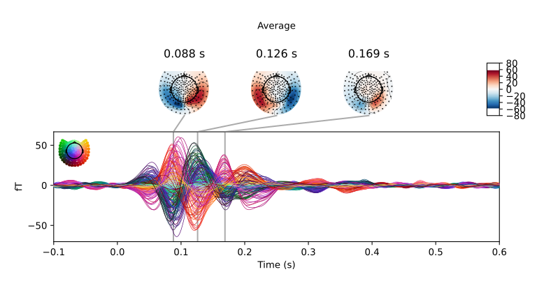

Grand Average Plot: Tark

#### Left Posterior Channels

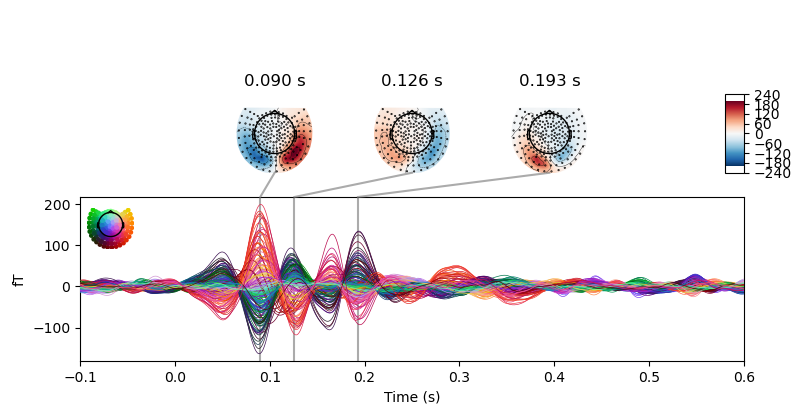

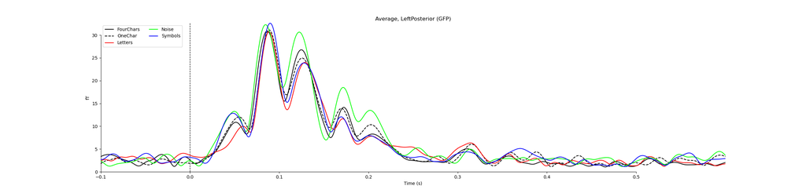

#### Right Posterior Channels

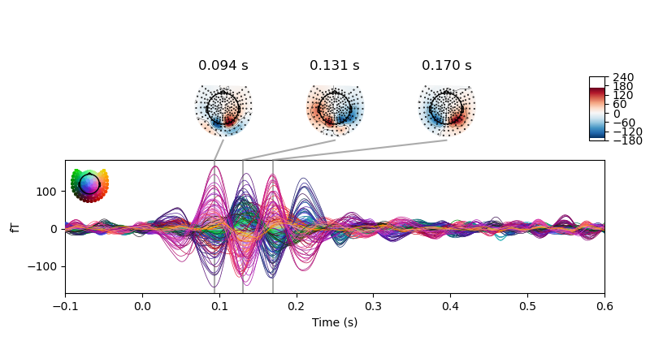

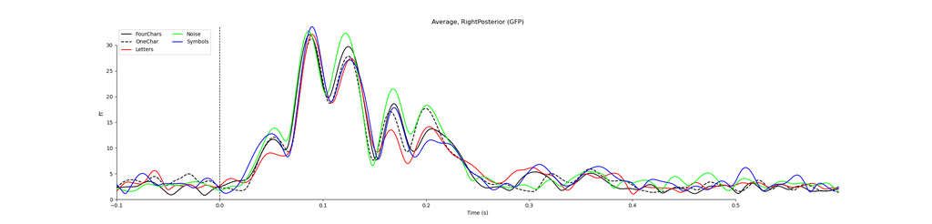

### TYPE I Noise Effect

**Noise Level** was coded as follows: 1: 0, 24: 1;

**Stimulus Type** was coded as follows: letter: 0, word: 1.

**Time window** : 80-130ms

params

```
samples = 10000
pmin = 0.05
mintime = 0.020
minsource = 20
```

**NO SIGNIFICANT CLUSTERS WERE IDENTIFIED for Type I noise**

Consequently no analyses were performed for Type II Noise effect.

### TYPE II Tark Localiser (130 - 180)ms - Bilateral occipital and temporal regions

StringType and Stimulus Type as predictors. String Type was coded as follows: symbols: 0, letters: 1; Stimulus Type was coded as follows: one element: 0, four elements:1 between 130-180ms in Bilateral Occipital and Temporal Regions.

**String Typel** was coded as follows: symbols: 0, letters: 1;

**Stimulus Type** was coded as follows: one element: 0, four elements:1

**Time window** : 130-180ms

```
Cluster:

130-161ms
vertices=1781.88
p=0.0943
```

```r
file_ws_rh <- "data/TC_Tark_RH.csv"
ws_min_rh = 130
ws_max_rh = 161
p_ws_rh = 0.0943


data <- read_csv(file_ws_rh, col_names = c("Time", "Participant", "Item.no", "cond", "type","hemi", "dSPM"))
data$Condition <- paste((data$cond),(data$type))
data$Time <- data$Time*1000
#unique(data$Condition)
wordVsymbols_rh <- data %>% filter(Participant != "B0025") %>%  filter(((cond == "word" & type =="clean") | (cond == "word" & type =="symbols") ))
wordVsymbols_rh$Condition[wordVsymbols_rh$Condition == "word clean" ] <- "Letter"
wordVsymbols_rh$Condition[wordVsymbols_rh$Condition == "word symbols" ] <- "Symbol"
wordVsymbols_rh <- wordVsymbols_rh %>%
                  dplyr::group_by(
                    Time,
                    Condition,
                    hemi
                  ) %>%
                  dplyr::summarise(
                    SE = std.error(dSPM),
                    dSPM = mean(dSPM)
                  )
wordVsymbols_rh <- wordVsymbols_rh %>% filter(hemi == "dSPM-rh.stc")
#wordVsymbols_lh$Condition = with(wordVsymbols_lh, reorder(Word, Symbols)
wordVsymbols_Bar_rh <- wordVsymbols_rh %>% filter(Time>= ws_min_rh & Time <= ws_max_rh) %>% dplyr::group_by(Condition) %>% dplyr::summarise(SE = std.error(dSPM), dSPM = mean(dSPM))
wordVsymbols_Bar_rh <- wordVsymbols_Bar_rh %>% mutate(Condition = as.factor(Condition))
wordVsymbols_Bar_rh$Condition <- relevel(wordVsymbols_Bar_rh$Condition, ref = "Letter")
```

```r
knitr::kable(wordVsymbols_Bar_rh)
```

| Condition | SE | dSPM |
| --- | --- | --- |
| Letter | 0.0825430 | -0.7949181 |
| Symbol | 0.0958094 | -0.1588367 |

```r
wordVsymbols_timeseries_rh <- ggplot(wordVsymbols_rh, aes(x = Time, y = dSPM, col = Condition, linetype = Condition)) +
  geom_line(aes(group = Condition),size = 1) +


  #annotate('rect',xmin=tmin, xmax=tmax, alpha=0.12,ymin=-Inf,ymax=Inf,fill="darkgrey") +
  annotate('text',x=(ws_min_rh + ws_max_rh)/2, y= 0.7, label ="*", size = 20) +
  annotate('rect',xmin=ws_min_rh, xmax=ws_max_rh, alpha=0.2,ymin=-Inf,ymax=Inf,fill="darkgrey") +
  # annotate('rect',xmin=tmin - 50, xmax=tmax + 50, alpha=0.1,ymin=-Inf,ymax=Inf,fill="green") +
  # annotate('rect',xmin=-Inf, xmax=tmin, alpha=0.075,ymin=-Inf,ymax=Inf,fill="#000000") +
  # annotate('rect',xmin=tmax, xmax=Inf, alpha=0.075,ymin=-Inf,ymax=Inf,fill="#666666") +
  # scale_colour_manual("",values=c("#E63946","#276FBF",  "#545083", "#FF8888", "#FF0000", "#FF8888")) +
  scale_colour_manual("",values=c("deeppink","dodgerblue",  "#545083", "#FF8888", "#FF0000", "#FF8888")) +
  scale_linetype_manual("",values=c("solid", "twodash", "solid", "dashed", "solid", "dashed")) +
  # scale_fill_manual("",values=c("#E63946","#545083",  "#545083", "#FF8888", "#FF0000", "#FF8888")) +
  geom_ribbon(aes(ymin = dSPM - SE, ymax = dSPM + SE, fill = Condition, group=Condition), alpha = 0.2, col = NA, show.legend = FALSE) +
  scale_y_continuous("Activation (dSPM)",expand=c(0,0), limits = c(-1.5, 1.5)) + scale_x_continuous("Time (ms)", expand=c(0,0), limits = c(-50, 350)) + theme(legend.position="bottom") +
   theme_minimal() + theme(panel.grid.major = element_blank(),
                                                   panel.grid.minor = element_blank(),
                                                   axis.title = element_text(size = 14, face = "bold"),
                                                   axis.text = element_text(size = 12), legend.position = "none") +

  geom_hline(yintercept=0, linetype="dotted") + geom_vline(xintercept=0, linetype="dotted")

wordVsymbols_bar_rh <- ggplot(wordVsymbols_Bar_rh, aes(x=Condition, y=dSPM,fill=Condition)) +
  geom_bar(stat = "identity", width = 0.7, position = position_dodge(0.7), show.legend = FALSE, color="#545083"  )+
  #scale_x_discrete(limits = Conditions) +  facet_wrap( ~Prefix) +
  ylab("dSPM") +
  xlab("Conditions") +
  scale_fill_manual("",values=c("deeppink","dodgerblue",  "#545083", "#FF8888", "#FF0000", "#FF8888")) +
  #theme_Publication()+
  # coord_cartesian(ylim = c(0, 1150)) +
  # scale_y_continuous(expand = expansion(mult = c(0, 0.05)))+
  # geom_signif(
  #   comparisons = list(c("Grammatical", "Pseudowords")),
  #   margin_top = 0.8,
  #   step_increase = 0.09,
  #   tip_length = 0.5,
  #   annotation = c("***")
  # )+
   geom_hline(yintercept=0, linetype="dotted") + geom_vline(xintercept=0, linetype="dotted") +
   theme_minimal() + theme(panel.grid.major = element_blank(),
                                                   panel.grid.minor = element_blank(),
                                                   axis.title = element_text(size = 14, face = "bold"),
                                                   axis.text = element_text(size = 12)) +
  #geom_errorbar function is used to plot error bars
  geom_errorbar(aes(ymin=dSPM-SE,
                     ymax=dSPM+SE,
                 width=0.3))
```

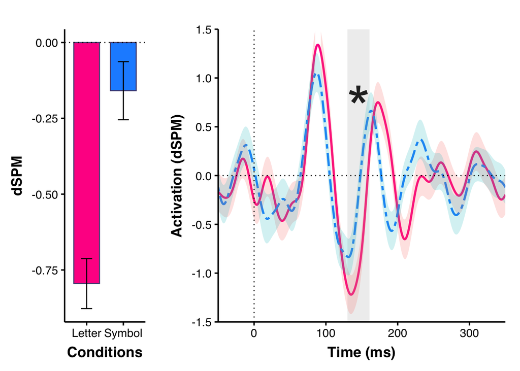

```r
Plot_wordSymbol_rh <-grid.arrange(wordVsymbols_bar_rh + theme_Publication_SwarMoi() ,(wordVsymbols_timeseries_rh + theme_Publication_SwarMoi() +theme(legend.position = "none")),nrow=1, widths=c(4,9))
```

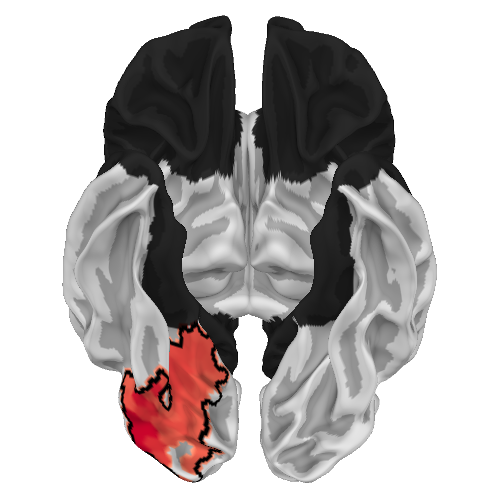

RH Cluster 130-161ms | p=0.0943

## POST DECOMPOSITION

```r
X <- tribble(
  ~Prefix, ~Condition, ~PrefixType,
  "CatViolDU", "CatViol", "DU",
  "CatViolPROTI", "CatViol","PROTI",
  "GrammDU", "Gramm","DU",
  "GrammPROTI", "Gramm","PROTI",
  "SemViolDU", "SemViol","DU",
  "SemViolPROTI", "SemViol","PROTI",
  "Filler", "Filler","Fill",
)
```

### TL: RH_TemporalLobe_244-286_p0.0197

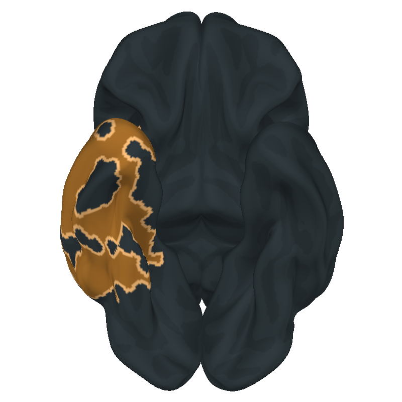

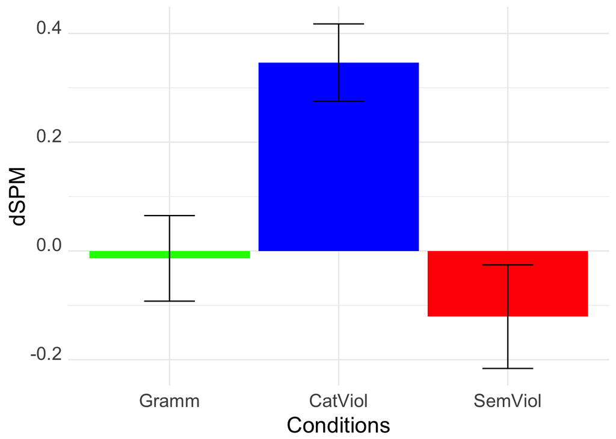

```r
RH_Temporal <- read_csv("data/SAVANT/CatViol_RH_244-286_p0.0197.csv", col_names = c("Participant", "Prefix","hemi", "dSPM"))
RH_Temporal = RH_Temporal %>% left_join(X)
RH_Temporal <- RH_Temporal %>% select(!hemi)  %>% group_by(Condition) %>% summarise(SE = std.error(dSPM),dSPM = mean(dSPM))
RH_Temporal_TC <- read_csv("data/SAVANT/TC_CatViol_RH_244-286_p0.0197.csv", col_names = c("time", "Participant", "Prefix","hemi", "dSPM"))
RH_Temporal_TC = RH_Temporal_TC %>% left_join(X)

RH_Temporal_TC$time = RH_Temporal_TC$time*1000

RH_Temporal_TC <- RH_Temporal_TC %>% filter(between(time, 244, 286)) %>% group_by(Condition) %>% summarise(SE = std.error(dSPM),
                    dSPM = mean(dSPM))

RH_temporal_plot <- RH_Temporal %>% filter(Condition != "Filler")  %>% ggplot(aes(x= factor(Condition, level = level_order),y=dSPM,fill=Condition)) +
  # geom_bar function is used to plot bars of barplot
  geom_bar(stat = "identity", width = 0.95, position = position_dodge(0.1), show.legend = FALSE  )+
  #scale_x_discrete(limits = Conditions) +  facet_wrap( ~Prefix) +
  ylab("dSPM") +
  xlab("Conditions") +
  scale_fill_manual(values = c("blue" , "green" ,"red"))+
   geom_errorbar(aes(ymin=dSPM-SE,
                    ymax=dSPM+SE,
                 width=0.3))+
  theme_minimal() +
  theme(axis.text.x = element_text(size = 15, angle = 0, hjust = .5, vjust = .5, face = "plain"),
        axis.text.y = element_text(size = 15, angle = 0, hjust = 1, vjust = 0, face = "plain"),
        axis.title.x = element_text(size = 18, angle = 0, hjust = .5, vjust = 0, face = "plain"),
        axis.title.y = element_text(size = 18, angle = 90, hjust = .5, vjust = .5, face = "plain"))

RH_temporal_plot
```

```r
knitr::kable(RH_Temporal)
```

| Condition | SE | dSPM |
| --- | --- | --- |
| CatViol | 0.0711853 | 0.3463524 |
| Filler | 0.0794799 | -0.0110849 |
| Gramm | 0.0786636 | -0.0136021 |
| SemViol | 0.0952327 | -0.1208228 |

### OF : LH OF 424-452_p0.0472

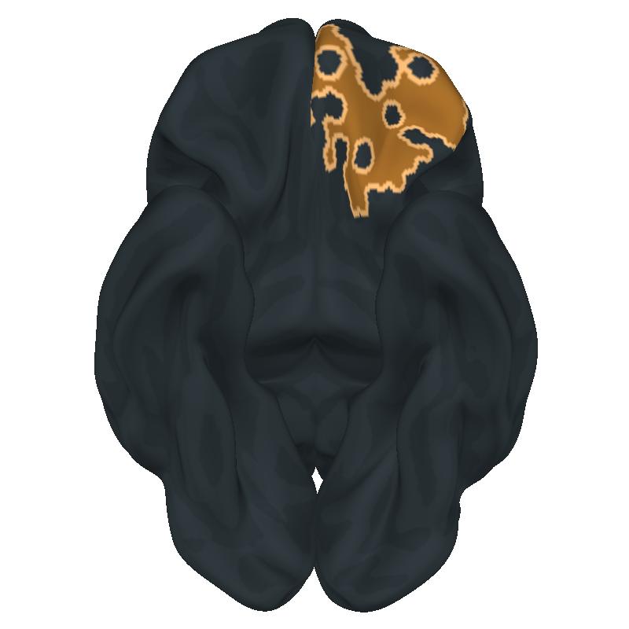

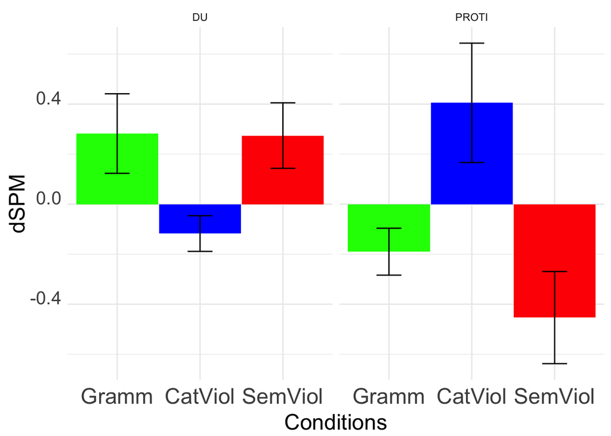

```r
LH_OF <- read_csv("data/SAVANT/OF_LH_424-452_p0.0472.csv", col_names = c("Participant", "Prefix","hemi", "dSPM"))
LH_OF = LH_OF %>% left_join(X)
LH_OF <- LH_OF %>% select(!hemi)  %>% group_by(Condition,Prefix, PrefixType) %>% summarise(SE = std.error(dSPM),
                    dSPM = mean(dSPM))
LH_OF_TC <- read_csv("data/SAVANT/TC_OF_LH_424-452_p0.0472.csv", col_names = c("time", "Participant", "Prefix","hemi", "dSPM"))
LH_OF_TC = LH_OF_TC %>% left_join(X)
LH_OF_TC$time = LH_OF_TC$time*1000
LH_OF_TC <- LH_OF_TC %>% filter(between(time, 424, 452)) %>% group_by(Condition, Prefix, PrefixType) %>% summarise(SE = std.error(dSPM),
                    dSPM = mean(dSPM))


LH_OF_plot <- LH_OF %>% filter(Condition != "Filler")  %>% ggplot(aes(x= factor(Condition, level = level_order),y=dSPM,fill=Condition)) +
  # geom_bar function is used to plot bars of barplot
  geom_bar(stat = "identity", width = 0.99, position = position_dodge(0.1), show.legend = FALSE  )+
  #scale_x_discrete(limits = Conditions) +  facet_wrap( ~Prefix) +
  ylab("dSPM") +
  xlab("Conditions") +
  facet_wrap(~PrefixType) +
  # scale_fill_manual(values = c("blue", "lightblue" , "green", "lightgreen" ,"red", "pink"))+
   scale_fill_manual(values = c("blue",  "green","red"))+
   geom_errorbar(aes(ymin=dSPM-SE,
                    ymax=dSPM+SE,
                 width=0.3))+
  theme_minimal() +
  theme(axis.text.x = element_text(size = 18, angle = 0, hjust = .5, vjust = .5, face = "plain"),
        axis.text.y = element_text(size = 15, angle = 0, hjust = 1, vjust = 0, face = "plain"),
        axis.title.x = element_text(size = 18, angle = 0, hjust = .5, vjust = 0, face = "plain"),
        axis.title.y = element_text(size = 18, angle = 90, hjust = .5, vjust = .5, face = "plain"))

LH_OF_plot
```

```r
knitr::kable(LH_OF)
```

| Condition | Prefix | PrefixType | SE | dSPM |
| --- | --- | --- | --- | --- |
| CatViol | CatViolDU | DU | 0.0713381 | -0.1174651 |
| CatViol | CatViolPROTI | PROTI | 0.2385963 | 0.4050528 |
| Filler | Filler | Fill | 0.0655281 | 0.1002821 |
| Gramm | GrammDU | DU | 0.1590589 | 0.2822480 |
| Gramm | GrammPROTI | PROTI | 0.0938074 | -0.1899715 |
| SemViol | SemViolDU | DU | 0.1309587 | 0.2741620 |
| SemViol | SemViolPROTI | PROTI | 0.1841838 | -0.4534022 |

## Exploratory Analysis

### OF : LH_OF Early (238-279_p0.0049)

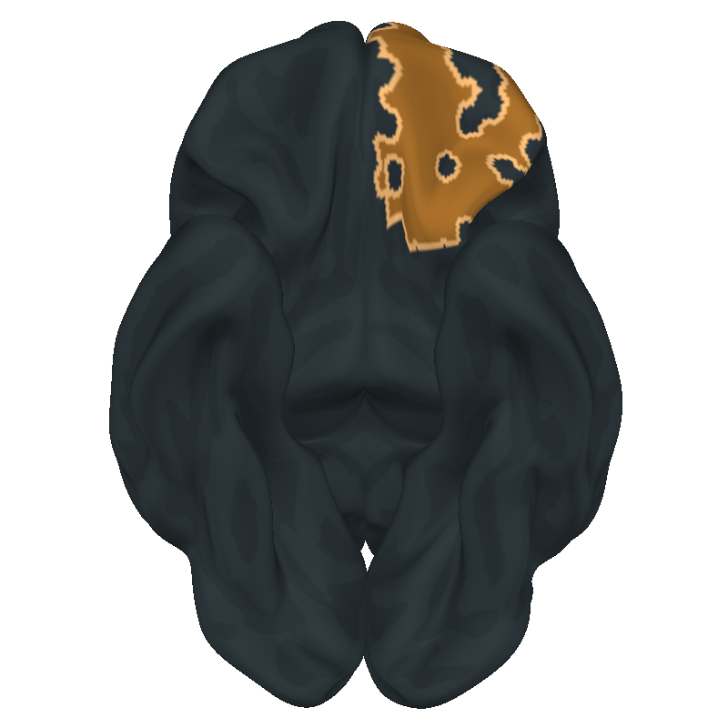

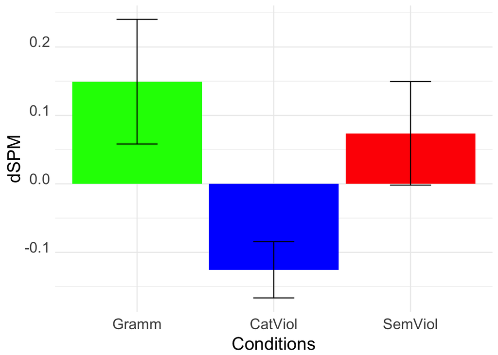

```r
LH_OF_early  <- read_csv("data/SAVANT/CatViol_LH_earlyOF_238-279_p0.0049.csv", col_names = c("Participant", "Prefix","hemi", "dSPM"))
LH_OF_early = LH_OF_early %>% left_join(X)

LH_OF_early <- LH_OF_early %>% select(!hemi)  %>% group_by(Condition) %>% summarise(SE = std.error(dSPM),
                    dSPM = mean(dSPM))
LH_OF_early_TC <- read_csv("data/SAVANT/TC_CatViol_LH_earlyOF_238-279_p0.0049.csv", col_names = c("time", "Participant", "Prefix","hemi", "dSPM"))
LH_OF_early_TC = LH_OF_early_TC %>% left_join(X)
LH_OF_early_TC$time = LH_OF_early_TC$time*1000
LH_OF_early_TC <- LH_OF_early_TC %>% filter(between(time, 238, 279)) %>% group_by(Condition) %>% summarise(SE = std.error(dSPM),
                    dSPM = mean(dSPM))

LH_OF_early_plot <- LH_OF_early %>% filter(Condition != "Filler")  %>% ggplot(aes(x= factor(Condition, level = level_order),y=dSPM,fill=Condition)) +
  # geom_bar function is used to plot bars of barplot
  geom_bar(stat = "identity", width = 0.95, position = position_dodge(0.1), show.legend = FALSE  )+
  #scale_x_discrete(limits = Conditions) +  facet_wrap( ~Prefix) +
  ylab("dSPM") +
  xlab("Conditions") +
  scale_fill_manual(values = c("blue" , "green" ,"red"))+
   geom_errorbar(aes(ymin=dSPM-SE,
                    ymax=dSPM+SE,
                 width=0.3))+
  theme_minimal() +
  theme(axis.text.x = element_text(size = 15, angle = 0, hjust = .5, vjust = .5, face = "plain"),
        axis.text.y = element_text(size = 15, angle = 0, hjust = 1, vjust = 0, face = "plain"),
        axis.title.x = element_text(size = 18, angle = 0, hjust = .5, vjust = 0, face = "plain"),
        axis.title.y = element_text(size = 18, angle = 90, hjust = .5, vjust = .5, face = "plain"))

LH_OF_early_plot
```

```r
knitr::kable(LH_OF_early)
```

| Condition | SE | dSPM |
| --- | --- | --- |
| CatViol | 0.0411778 | -0.1254958 |
| Filler | 0.0313287 | -0.0434605 |
| Gramm | 0.0910601 | 0.1492997 |
| SemViol | 0.0756533 | 0.0737754 |